# profilepoint analysis alluvial deposits

fabian gruber

October 24, 2017

0 1 6 7

[1] “OBB error with all predictors of allpreds is 0.0769230769230769” [1] “OBB error with all predictors of roughness is 0.0769230769230769” [1] “OBB error with all predictors of localterrain is 0.692307692307692”

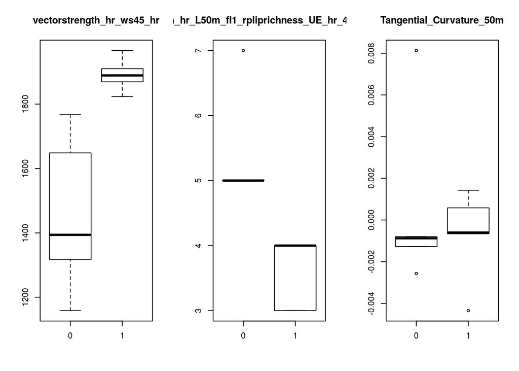

How are these points morphometrically different from others For instance different to till in general

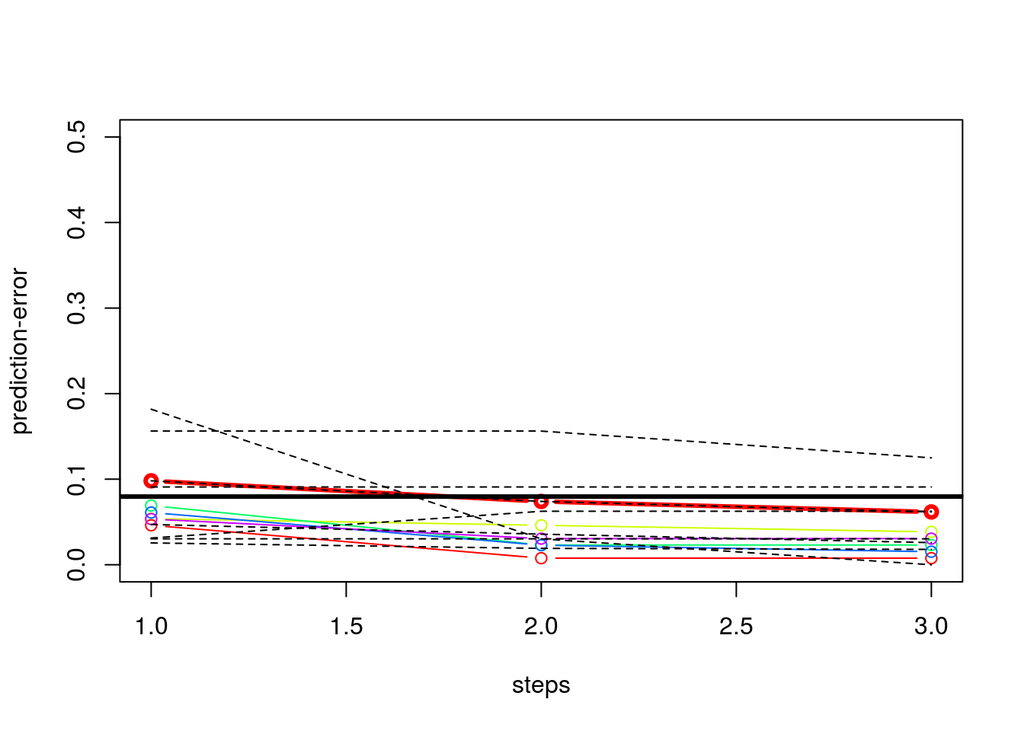

[1] “Prediction error at end is: 0.0981060606060606” [2] “Prediction error at end is: 0.0740530303030303” [3] “Prediction error at end is: 0.0617424242424242” k 1 k 2 1 elev_ws15_10m maxic_ws11_10m 2 geom_hr_L3_fl10_rplipsimpson_UE_hr_60cells_hr elev_ws11_10m 3 geom_hr_L3_fl1_rplippatchnum_UE_hr_60cells_hr elev_ws5_10m k 3 k 4 1 elev_ws11_10m elev_ws11_10m 2 geom_hr_L3_fl1_rplippatchdensity_UE_hr_60cells_hr dtm_hr_TEXTURE_r5 3 geom_hr_L3_fl1_rplipshannon_UE_hr_5cells_hr TRI_hr_ws5 k 5 1 dtm_hr_TEXTURE_r5 2 profc_DTM_50m_avg_ws5_50m 3 elev_ws11_10m [1] “OBB error with all predictors of allpreds is 0.0613496932515337”

|  | AD | TG | MeanDecreaseAccuracy | MeanDecreaseGini |
| --- | --- | --- | --- | --- |
| elev_ws11_10m | 0.0329619 | 0.0035303 | 0.0058178 | 0.9060285 |
| elev_ws3_10m | 0.0336905 | 0.0033139 | 0.0056759 | 0.7972556 |
| elev_ws5_10m | 0.0338643 | 0.0032945 | 0.0055023 | 0.9671085 |
| elev_ws15_10m | 0.0298214 | 0.0022073 | 0.0041404 | 0.6182248 |
| Channel_Network_Base_Level_hr | 0.0157595 | 0.0015572 | 0.0025022 | 0.6004329 |
| Standardized_Height_50m | 0.0073857 | 0.0012236 | 0.0016625 | 0.2778127 |
| ChannelNetworkBaseLevel_10m | 0.0038524 | 0.0010437 | 0.0013002 | 0.2841056 |
| Convexity_50m | 0.0080675 | 0.0006189 | 0.0012466 | 0.3532775 |
| Relative_Slope_Position_50m | 0.0059690 | 0.0008111 | 0.0012235 | 0.2796768 |
| Mass_Balance_Index_50m | 0.0047357 | 0.0008327 | 0.0011792 | 0.3067863 |

[1] “OBB error with all predictors of roughness is 0.0674846625766871”

|  | AD | TG | MeanDecreaseAccuracy | MeanDecreaseGini |
| --- | --- | --- | --- | --- |
| TRI_hr_ws1 | 0.0078238 | 0.0039119 | 0.0041673 | 0.2456003 |
| dtm_hr_TEXTURE_r20 | 0.0038190 | 0.0021028 | 0.0022344 | 0.1325983 |
| TRI_hr_ws2 | 0.0045095 | 0.0020170 | 0.0021170 | 0.2532549 |
| TRI_hr_ws3 | 0.0028524 | 0.0018089 | 0.0018810 | 0.1243047 |
| geom_hr_L3_fl1_rplipdominance_UE_hr_60cells_hr | 0.0013238 | 0.0017663 | 0.0018128 | 0.2651756 |
| TRI_hr_ws6 | 0.0000190 | 0.0018257 | 0.0016705 | 0.1206727 |
| TRI_hr_ws50 | 0.0008857 | 0.0015241 | 0.0014665 | 0.1151848 |
| TRI_hr_ws31 | 0.0000000 | 0.0014379 | 0.0013088 | 0.0743614 |
| fischerk_ws3_hr | 0.0085429 | 0.0006818 | 0.0012744 | 0.3080813 |
| fischerk_ws7_hr | 0.0025905 | 0.0010764 | 0.0012732 | 0.1146339 |

[1] “OBB error with all predictors of localterrain is 0.0736196319018405”

|  | AD | TG | MeanDecreaseAccuracy | MeanDecreaseGini |
| --- | --- | --- | --- | --- |
| longc_ws15_10m | 0.0249238 | 0.0012622 | 0.0030996 | 0.6609252 |
| minic_DTM_50m_avg_ws5_50m | 0.0081024 | 0.0018231 | 0.0022749 | 0.2837379 |
| Slope_hr | 0.0055857 | 0.0019026 | 0.0021392 | 0.1925511 |
| longc_ws11_10m | 0.0056849 | 0.0015826 | 0.0019003 | 0.3477363 |
| Convexity_50m | 0.0148484 | 0.0006691 | 0.0018348 | 0.8701467 |
| profc_DTM_50m_avg_ws3_50m | 0.0035190 | 0.0015050 | 0.0016924 | 0.3871036 |
| slope_ws3_hr_hr | 0.0011000 | 0.0016723 | 0.0015627 | 0.2441007 |
| longc_DTM_50m_avg_ws3_50m | 0.0059627 | 0.0010782 | 0.0015530 | 0.4504931 |
| profc_ws15_10m | 0.0112214 | 0.0008192 | 0.0015503 | 0.4320694 |
| planc_DTM_50m_avg_ws9_50m | -0.0009000 | 0.0017277 | 0.0015354 | 0.1190729 |

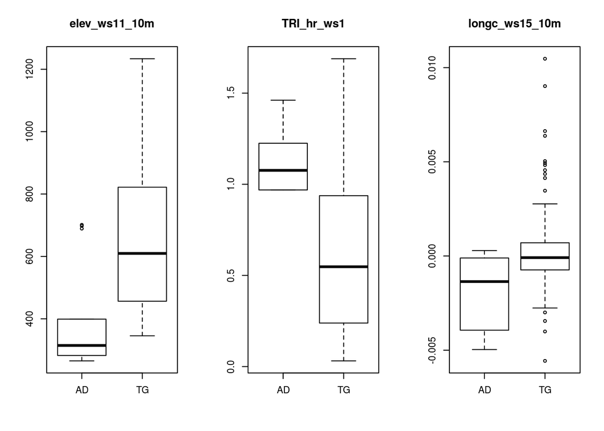

How does this compare to the differences between the units on the geological map?

[1] “OBB error with all predictors of allpreds is 0.0439804531319414”

|  | AD | TG | MeanDecreaseAccuracy | MeanDecreaseGini |
| --- | --- | --- | --- | --- |
| elev_ws11_10m | 0.0514030 | 0.0475113 | 0.0490146 | 141.02615 |
| elev_ws5_10m | 0.0563215 | 0.0408130 | 0.0465477 | 125.42202 |
| elev_ws15_10m | 0.0536590 | 0.0399101 | 0.0449481 | 116.30966 |
| elev_ws3_10m | 0.0485979 | 0.0369448 | 0.0412865 | 105.54145 |
| Channel_Network_Base_Level_hr | 0.0434919 | 0.0376691 | 0.0398241 | 101.31477 |
| Standardized_Height_50m | 0.0401224 | 0.0223339 | 0.0289068 | 87.93420 |
| ChannelNetworkBaseLevel_10m | 0.0347576 | 0.0239176 | 0.0279786 | 75.13921 |
| Vertical_Distance_to_Channel_Network_50m | 0.0310045 | 0.0082613 | 0.0166206 | 54.31005 |
| Normalized_Height_50m | 0.0238209 | 0.0103551 | 0.0153596 | 59.42324 |
| Relative_Slope_Position_50m | 0.0270463 | 0.0083699 | 0.0152929 | 49.54345 |

[1] “OBB error with all predictors of roughness is 0.123445825932504”

|  | AD | TG | MeanDecreaseAccuracy | MeanDecreaseGini |
| --- | --- | --- | --- | --- |
| dtm_hr_TEXTURE_r30 | 0.0328857 | 0.0232400 | 0.0268394 | 76.70231 |
| TRI_hr_ws49 | 0.0290896 | 0.0106196 | 0.0174406 | 49.36119 |
| TRI_hr_ws50 | 0.0213072 | 0.0143572 | 0.0169090 | 61.94093 |
| dtm_hr_TEXTURE_r20 | 0.0170175 | 0.0155737 | 0.0160847 | 46.04268 |
| geom_hr_L3_fl1_rplipsimpson_UE_hr_60cells_hr | 0.0073692 | 0.0204811 | 0.0156464 | 21.62460 |
| TRI_hr_ws47 | 0.0221718 | 0.0096763 | 0.0142646 | 47.73895 |
| TRI_hr_ws48 | 0.0188382 | 0.0095214 | 0.0129587 | 40.72321 |
| TRI_hr_ws45 | 0.0187455 | 0.0090892 | 0.0126825 | 37.59232 |
| geom_hr_L3_fl1_rplipshannon_UE_hr_60cells_hr | 0.0046763 | 0.0154614 | 0.0114446 | 18.08713 |
| TRI_hr_ws43 | 0.0171698 | 0.0077609 | 0.0112816 | 36.73455 |

[1] “OBB error with all predictors of localterrain is 0.0979827089337176”

|  | AD | TG | MeanDecreaseAccuracy | MeanDecreaseGini |
| --- | --- | --- | --- | --- |
| Convexity_50m | 0.0574694 | 0.0387492 | 0.0457221 | 137.99512 |
| slope_DTM_50m_avg_ws5_50m | 0.0457770 | 0.0186432 | 0.0287227 | 92.99921 |
| slope_DTM_50m_avg_ws7_50m | 0.0297396 | 0.0126111 | 0.0190008 | 89.90363 |
| slope_ws15_10m | 0.0243064 | 0.0138071 | 0.0176816 | 76.71781 |
| maxic_DTM_50m_avg_ws11_50m | 0.0269423 | 0.0117236 | 0.0173717 | 30.28748 |
| slope_DTM_50m_avg_ws3_50m | 0.0219657 | 0.0140082 | 0.0169185 | 85.65859 |
| slope_DTM_50m_avg_ws9_50m | 0.0199090 | 0.0141304 | 0.0162737 | 50.37709 |
| profc_DTM_50m_avg_ws11_50m | 0.0282441 | 0.0085615 | 0.0158772 | 27.61255 |
| longc_DTM_50m_avg_ws11_50m | 0.0237263 | 0.0082657 | 0.0140043 | 26.35760 |
| maxic_DTM_50m_avg_ws9_50m | 0.0242484 | 0.0070668 | 0.0134665 | 23.55534 |

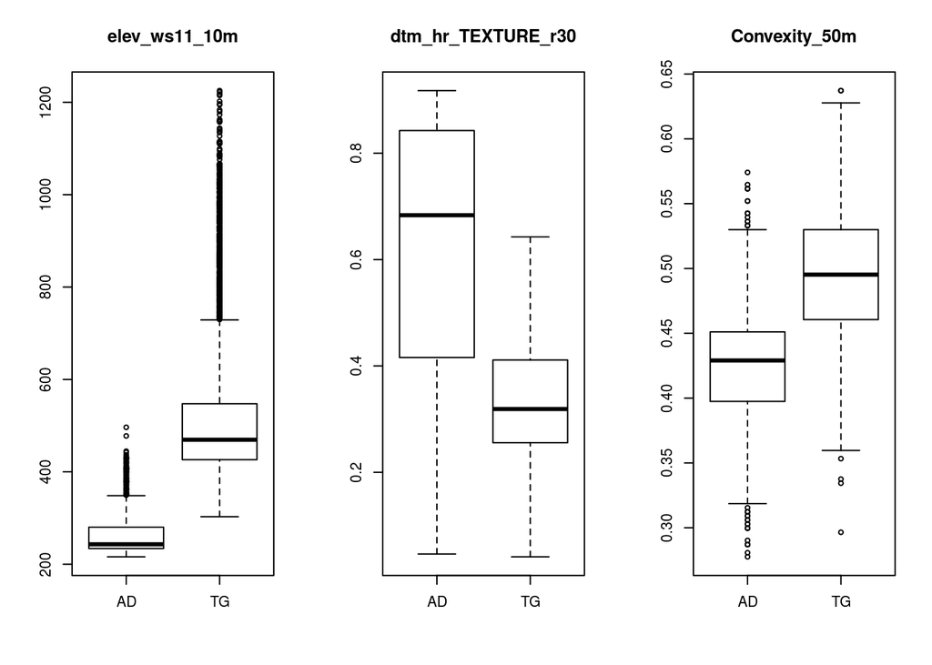

How about Debris cones

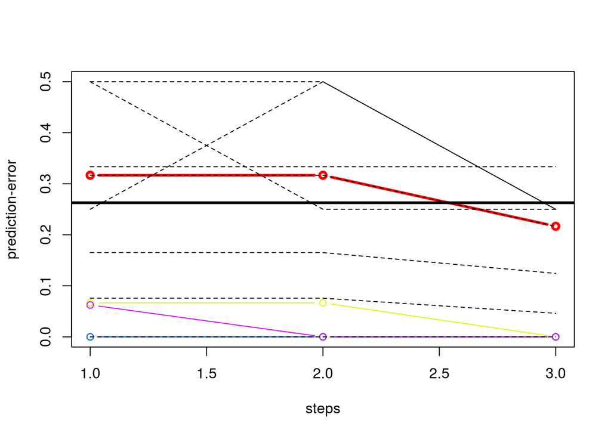

[1] “Prediction error at end is: 0.316666666666667” [2] “Prediction error at end is: 0.316666666666667” [3] “Prediction error at end is: 0.216666666666667” k 1 k 2 1 fischerk_ws11_hr longc_DTM_50m_avg_ws7_50m 2 fischerk_ws13_hr profc_DTM_50m_avg_ws7_50m 3 vectorstrength_hr_ws11_hr crosc_DTM_50m_avg_ws9_50m k 3 k 4 1 planc_DTM_50m_avg_ws7_50m longc_DTM_50m_avg_ws7_50m 2 Catchment_slope_50m profc_DTM_50m_avg_ws7_50m 3 Texture_50m minic_ws5_10m k 5 1 minic_ws5_10m 2 crosc_ws15_hr_hr 3 Flow_Line_Curvature_hr [1] “OBB error with all predictors of allpreds is 0.263157894736842”

|  | AD | DC | MeanDecreaseAccuracy | MeanDecreaseGini |
| --- | --- | --- | --- | --- |
| Texture_50m | 0.0072667 | 0.0118333 | 0.0082143 | 0.3048059 |
| Catchment_slope_50m | 0.0042857 | 0.0098333 | 0.0053825 | 0.2287987 |
| profc_ws23_hr_hr | 0.0028548 | 0.0080000 | 0.0044524 | 0.0852926 |
| vectorruggedness_hr_ws39 | 0.0044000 | 0.0043333 | 0.0039238 | 0.0677149 |
| minic_ws23_hr_hr | 0.0016333 | 0.0070000 | 0.0028000 | 0.1394752 |
| dtm_hr_CONVEX_r10 | 0.0020667 | 0.0036667 | 0.0027143 | 0.0694129 |
| longc_ws23_hr_hr | 0.0025000 | 0.0030000 | 0.0026270 | 0.1265364 |
| vectorruggedness_hr_ws31 | 0.0020000 | 0.0056667 | 0.0024881 | 0.0872853 |
| minic_DTM_50m_avg_ws7_50m | 0.0016333 | 0.0036667 | 0.0021810 | 0.0867252 |
| slope_ws13_hr_hr | 0.0025000 | 0.0011667 | 0.0019048 | 0.0363208 |

[1] “OBB error with all predictors of roughness is 0.421052631578947”

|  | AD | DC | MeanDecreaseAccuracy | MeanDecreaseGini |
| --- | --- | --- | --- | --- |
| Texture_50m | 0.0041857 | 0.0136667 | 0.0066373 | 0.2491038 |
| vectorruggedness_hr_ws39 | 0.0053190 | 0.0036667 | 0.0048810 | 0.0835179 |
| geom_hr_L3_fl10_rplippatchnum_UE_hr_60cells_hr | 0.0049000 | 0.0060000 | 0.0048357 | 0.0931086 |
| geom_hr_L3_fl10_rplipmps_UE_hr_40cells_hr | 0.0035857 | 0.0026667 | 0.0032381 | 0.0920914 |
| TRI_hr_ws1 | 0.0025333 | 0.0056667 | 0.0032381 | 0.0867488 |
| geom_hr_L3_fl10_rplippatchdensity_UE_hr_60cells_hr | 0.0030024 | 0.0016667 | 0.0027556 | 0.1095689 |
| TRI_hr_ws6 | 0.0024333 | 0.0040000 | 0.0024429 | 0.0722882 |
| geom_hr_L3_fl10_rplipmps_UE_hr_60cells_hr | 0.0031000 | 0.0006667 | 0.0022341 | 0.0830345 |
| geom_hr_L50m_fl1_rplipsimpson_UE_hr_5cells_hr | 0.0023000 | 0.0013333 | 0.0021548 | 0.0196667 |
| TRI_hr_ws3 | 0.0020667 | 0.0013333 | 0.0021429 | 0.0604209 |

[1] “OBB error with all predictors of localterrain is 0.315789473684211”

|  | AD | DC | MeanDecreaseAccuracy | MeanDecreaseGini |
| --- | --- | --- | --- | --- |
| dtm_hr_CONVEX_r10 | 0.0078833 | 0.0146667 | 0.0098270 | 0.2149125 |
| profc_ws23_hr_hr | 0.0066333 | 0.0171667 | 0.0089738 | 0.2464871 |
| minic_ws23_hr_hr | 0.0065667 | 0.0140000 | 0.0076476 | 0.1995538 |
| longc_ws23_hr_hr | 0.0067000 | 0.0090000 | 0.0070302 | 0.1670127 |
| longc_ws7_10m | 0.0038667 | 0.0073333 | 0.0049238 | 0.1049727 |
| minic_DTM_50m_avg_ws9_50m | 0.0031048 | 0.0068333 | 0.0040079 | 0.1179106 |
| minic_DTM_50m_avg_ws7_50m | 0.0034857 | 0.0045000 | 0.0037730 | 0.1729835 |
| minic_ws7_10m | 0.0027024 | 0.0066667 | 0.0035865 | 0.1032409 |
| planc_DTM_50m_avg_ws11_50m | 0.0020000 | 0.0090000 | 0.0034071 | 0.2398650 |
| profc_DTM_50m_avg_ws7_50m | 0.0017524 | 0.0083333 | 0.0033405 | 0.1561145 |

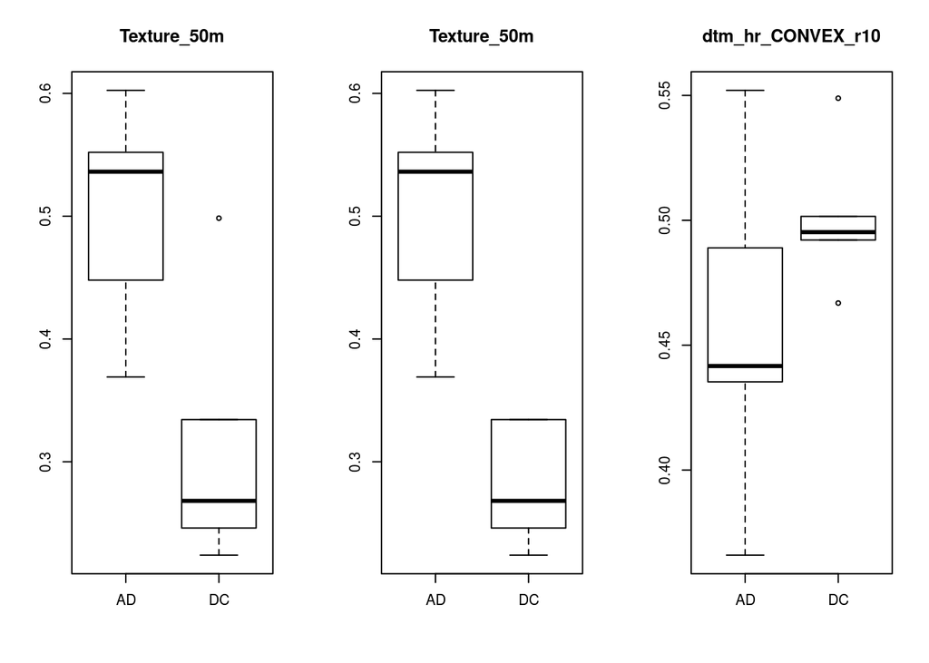

How does this compare to the differences between the units on the geological map?

[1] “OBB error with all predictors of allpreds is 0.0453951665578054”

|  | AD | DC | MeanDecreaseAccuracy | MeanDecreaseGini |
| --- | --- | --- | --- | --- |
| Catchment_slope_50m | 0.0113790 | 0.0485890 | 0.0283686 | 59.29065 |
| Texture_50m | 0.0262086 | 0.0204911 | 0.0235478 | 39.47540 |
| Channel_Network_Base_Level_hr | 0.0205070 | 0.0252072 | 0.0226571 | 25.49502 |
| ChannelNetworkBaseLevel_10m | 0.0188014 | 0.0234775 | 0.0209020 | 19.92506 |
| elev_ws15_10m | 0.0210976 | 0.0204098 | 0.0207792 | 19.88449 |
| elev_ws3_10m | 0.0178796 | 0.0213761 | 0.0193826 | 21.88754 |
| elev_ws5_10m | 0.0185050 | 0.0201955 | 0.0192595 | 21.30983 |
| elev_ws11_10m | 0.0174463 | 0.0213376 | 0.0191973 | 24.13953 |
| fischerk_ws61_hr | 0.0210526 | 0.0153232 | 0.0184311 | 51.57142 |
| Channel_Network_Base_Level_50m | 0.0146276 | 0.0216087 | 0.0177706 | 19.45086 |

[1] “OBB error with all predictors of roughness is 0.117819843342037”

|  | AD | DC | MeanDecreaseAccuracy | MeanDecreaseGini |
| --- | --- | --- | --- | --- |
| Texture_50m | 0.0372735 | 0.0475189 | 0.0418505 | 60.37158 |
| fischerk_ws61_hr | 0.0242242 | 0.0225417 | 0.0235271 | 44.37860 |
| vectorstrength_hr_ws61_hr | 0.0218089 | 0.0230608 | 0.0223847 | 38.38659 |
| vectorstrength_hr_ws59_hr | 0.0212197 | 0.0198401 | 0.0205078 | 35.81140 |
| fischerk_ws59_hr | 0.0195196 | 0.0191180 | 0.0193825 | 38.51235 |
| vectorstrength_hr_ws57_hr | 0.0172382 | 0.0168198 | 0.0170057 | 32.39028 |
| vectorstrength_hr_ws53_hr | 0.0157771 | 0.0170658 | 0.0163518 | 35.16437 |
| fischerk_ws55_hr | 0.0195567 | 0.0123412 | 0.0162820 | 34.46879 |
| fischerk_ws57_hr | 0.0161768 | 0.0148437 | 0.0155195 | 37.23780 |
| vectorstrength_hr_ws55_hr | 0.0176989 | 0.0123394 | 0.0152027 | 25.53730 |

[1] “OBB error with all predictors of localterrain is 0.104390243902439”

|  | AD | DC | MeanDecreaseAccuracy | MeanDecreaseGini |
| --- | --- | --- | --- | --- |
| slope_DTM_50m_avg_ws5_50m | 0.0271215 | 0.0700444 | 0.0466231 | 65.94014 |
| slope_DTM_50m_avg_ws7_50m | 0.0232618 | 0.0534703 | 0.0369200 | 53.07929 |
| slope_ws15_10m | 0.0152110 | 0.0516096 | 0.0317302 | 65.26893 |
| slope_DTM_50m_avg_ws3_50m | 0.0189711 | 0.0457036 | 0.0311691 | 61.07701 |
| slope_DTM_50m_avg_ws9_50m | 0.0163624 | 0.0446613 | 0.0291772 | 52.03087 |
| slope_DTM_50m_avg_ws11_50m | 0.0095573 | 0.0400302 | 0.0234411 | 42.23756 |
| Slope_50m | 0.0114553 | 0.0317436 | 0.0207209 | 47.63453 |
| slope_ws11_10m | 0.0085174 | 0.0296487 | 0.0181392 | 38.20319 |
| Slope_10m | 0.0091830 | 0.0195375 | 0.0138748 | 33.94493 |
| Slope_hr | 0.0021615 | 0.0275746 | 0.0137270 | 39.09139 |

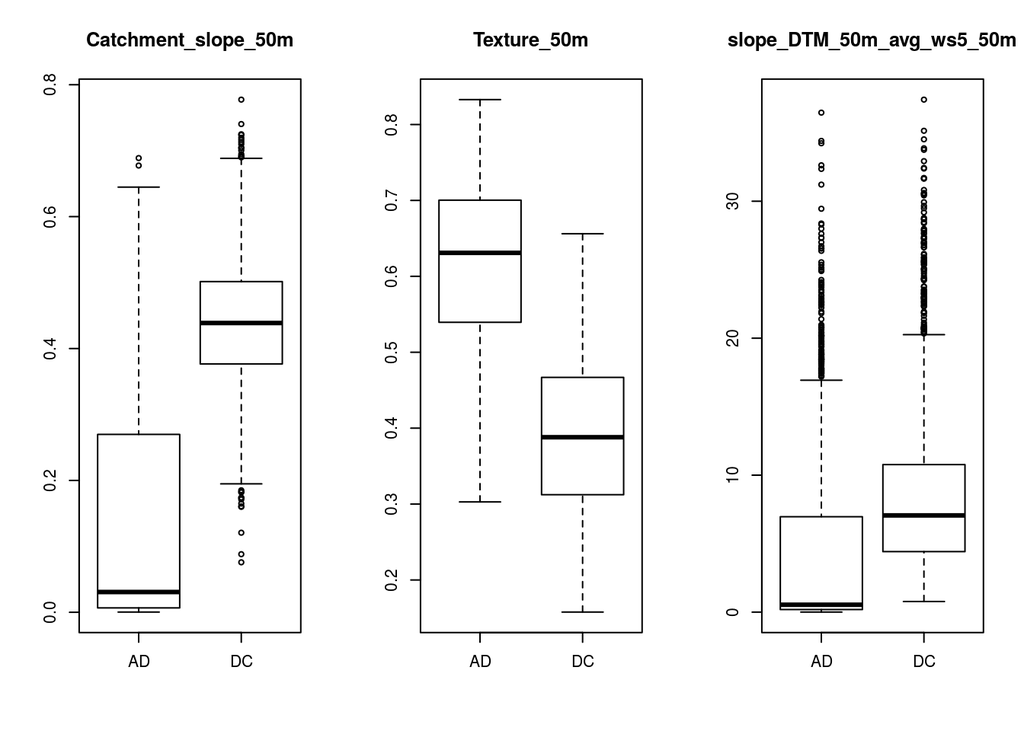